# Advanced statistics for physics analysis - Exercise 7

Matteo Bortoletto, matr. 1242935

30/05/2020

## Exercise 1

A researcher has collected $n = 15$ observations that are supposed to come from a Normal distribution with known variance $\sigma^2 = 16$:

`26.8, 26.3, 28.3, 28.5, 16.3, 31.9, 28.5, 27.2, 20.9, 27.5, 28.0, 18.6, 22.3, 25.0, 31.5`

Assuming a normal prior for $\mu$, $\mathcal{N}(m=20, s^2=25)$:

1. Determine the posterior distribution $P(\mu | y_1,\dots,y_{15})$ and find the posterior mean and standard deviation.

```r
library(latex2exp)

s.known <- 4
N <- 15
data <- c(26.8, 26.3, 28.3, 28.5, 16.3, 31.9, 28.5, 27.2, 20.9, 27.5, 28.0, 18.6, 22.3, 25.0, 31.5)
m.data <- mean(data)
s.prior <- 5
m.prior <- 20
s.post <- s.known*s.prior/(sqrt(s.known^2+N*s.prior^2))
m.post <- (s.post^2)*(m.prior/s.prior^2 + m.data*N/s.known^2)

mu <- seq(1, 60, 0.1)
post <- dnorm(mu, m.post, s.post)
```

The mean of the posterior is $\bar{\mu} = 25.601023$ and the standard deviation is $\sigma_{post} = 1.0114435$.

2. Find the 95% credibility interval for $\mu$.

```r
mu1 <- mu[which.min(abs(0.025-cumsum(post)*0.1))]
mu2 <- mu[which.min(abs(0.975-cumsum(post)*0.1))]
```

The 95% credibility interval is given by $[\mu_1,\mu_2] = [23.6, 27.5]$.

3. Plot the posterior distribution, indicating on the same plot: the mean value, the standard deviation, and the 95% credibility interval.

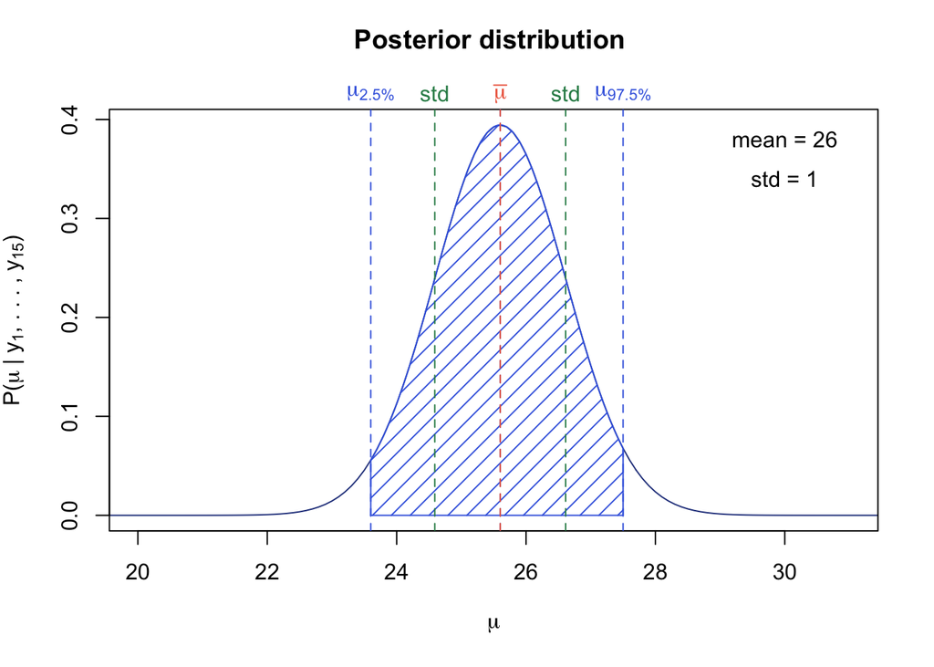

```r
options(repr.plot.width=12, repr.plot.height=10)

mu.p <- seq(mu1, mu2, 0.01)
x <- c(mu1, mu.p, mu2)
post.95 <- dnorm(mu.p, m.post, s.post)
y <- c(0, post.95, 0)

plot(mu, post,
     type = "l",
     xlim = c(20, 31),
     col = "royalblue4",
     xlab = TeX("$\\mu$"),
     ylab = TeX("P($\\mu$ | y_1,...,y_{15})"),
     main = "Posterior distribution \n")

text(30, 0.38, paste("mean =", round(m.post,0)))
text(30, 0.34, paste("std =", round(s.post,1)))
abline(v = m.post, lty = 2, col = "royalblue3")
polygon(x=x, y=y, col='royalblue', density = 10)

abline(v=m.post, col="coral2", lty=2)
abline(v=mu1, col="royalblue", lty=2)
abline(v=mu2, col="royalblue", lty=2)
abline(v=m.post+s.post, col="seagreen", lty=2)
abline(v=m.post-s.post, col="seagreen", lty=2)
text(m.post,
     par("usr")[4] + 0.035,
     labels = TeX("$\\bar{\\mu}$"),
     pos = 1, cex = 1, col="coral2", xpd=TRUE)
text(m.post+s.post,
     par("usr")[4] + 0.035,
     labels="std",
     pos=1, cex=1, col="seagreen", xpd=TRUE)
text(m.post-s.post,
     par("usr")[4] + 0.035,
     labels="std",
     pos=1, cex=1, col="seagreen", xpd=TRUE)
text(mu1,
     par("usr")[4] + 0.035,
     labels=TeX("$\\mu_{2.5%}$"),
     pos = 1, cex = 1, col="royalblue", xpd=TRUE)
text(mu2,
     par("usr")[4] + 0.035,
     labels=TeX("$\\mu_{97.5%}$"),
     pos = 1, cex = 1, col="royalblue", xpd=TRUE)
```

4. repeat the analysis using a different prior $\mathcal{N}(m=30, s^2=16)$ and plot, on the same graph the likelihood, the prior and the posterior.

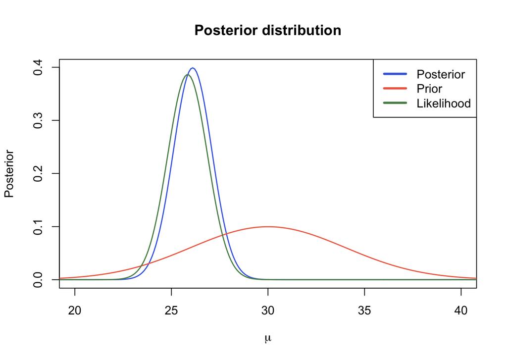

```r
s.prior <- 4
m.prior <- 30

prior.new <- dnorm(mu, m.prior, s.prior)

likelihood <- rep(1, length(mu))
for(x in data) {
  for(u in seq(0, length(mu))) {
    likelihood[u] <- likelihood[u]*dnorm(x, mu[u], 4)
  }
  likelihood <- likelihood/sum(likelihood)
}

likelihood.norm <- likelihood/(sum(likelihood)*0.1)

s.post <- s.known*s.prior/(sqrt(s.known^2+N*s.prior^2))
m.post <- (s.post^2)*(m.prior/s.prior^2 + m.data*N/s.known^2)

post.new <- dnorm(mu, m.post, s.post)/sum(dnorm(mu, m.post, s.post)*0.1)

plot(mu, post.new,
     xlim = c(20,40),
     type = "l",
     lwd = 1.5,
     col = "royalblue",
     xlab = TeX("$\\mu$"),
     ylab = "Posterior",
     main = "Posterior distribution")

lines(mu, prior.new,
      lwd = 1.5,
      type = "l",
      col = "coral2")

lines(mu, likelihood.norm,
      lwd = 1.5,
      type = "l",
      col = "palegreen4")

legend("topright",
       c("Posterior", "Prior", "Likelihood"),
       col = c("royalblue", "coral2", "palegreen4"),
       lwd = 3)
```

5. Compare the credibility intervals obtained with the two priors.

```r
mu1.new <- mu[which.min(abs(0.025-cumsum(post.new)*0.1))]
mu2.new <- mu[which.min(abs(0.975-cumsum(post.new)*0.1))]
```

The 95% credibility interval is given by $[\mu_1,\mu_2] = [24.1, 28]$.

## Exercise 2

A researcher has collected $n = 16$ observations that are supposed to come from a Normal distribution with known variance $\sigma^2 = 4$:

`4.09, 4.68, 1.87, 2.62, 5.58, 8.68, 4.07, 4.78, 4.79, 4.49, 5.85, 5.09, 2.40, 6.27, 6.30, 4.47`

Assuming the prior is a step function:

$$g(\mu) =
\begin{cases}
\mu & \text{for } 0<\mu\le 3 \\
3 & \text{for } 3<\mu\le 5 \\
8-\mu & \text{for } 5<\mu\le 8 \\
0 & \text{for } \mu > 8
\end{cases}$$

1. Find the posterior distribution, the posterior mean and standard deviation.

```r
n <- 16
s.known <- 2
data <- c(4.09, 4.68, 1.87, 2.62, 5.58, 8.68, 4.07, 4.78, 4.79, 4.49, 5.85, 5.09, 2.40, 6.27, 6.30, 4.47)

prior <- function(mu) {
  val <- ifelse(0 < mu & mu <= 3, mu,
                ifelse(3 < mu & mu <= 5, 3,
                       ifelse(5 < mu & mu <= 8, 8 - mu, 0)))
  return(val)
}

mu <- seq(0,10,0.01)

likelihood <- rep(1, length(mu))
for(x in data) {
  for(u in seq(0, length(mu))) {
    likelihood[u] <- likelihood[u]*dnorm(x, mu[u], 2)
  }
  likelihood <- likelihood/sum(likelihood)
}

likelihood.norm <- likelihood/(sum(likelihood)*0.01)

post.star <- likelihood.norm*prior(mu)
post.norm <- post.star/(sum(post.star)*0.01)

mu.mean <- sum(post.norm*mu*0.01)
post.std <- sqrt(sum(post.norm*0.01*mu^2)-mu.mean^2)
```

The posterior mean is $\bar{\mu} = 4.7251879$ and the standard deviation is $\sigma_{post} = 0.4837864$.

2. Find the 95% credibility interval for $\mu$.

```r
mu1 <- mu[which.min(abs(0.025-cumsum(post.norm)*0.01))]
mu2 <- mu[which.min(abs(0.975-cumsum(post.norm)*0.01))]
```

The 95% credibility interval is given by $[\mu_1,\mu_2] = [3.76, 5.66]$.

3. Plot the posterior distribution, indicating on the same plot: the mean value, the standard deviation, and the 95% credibility interval.

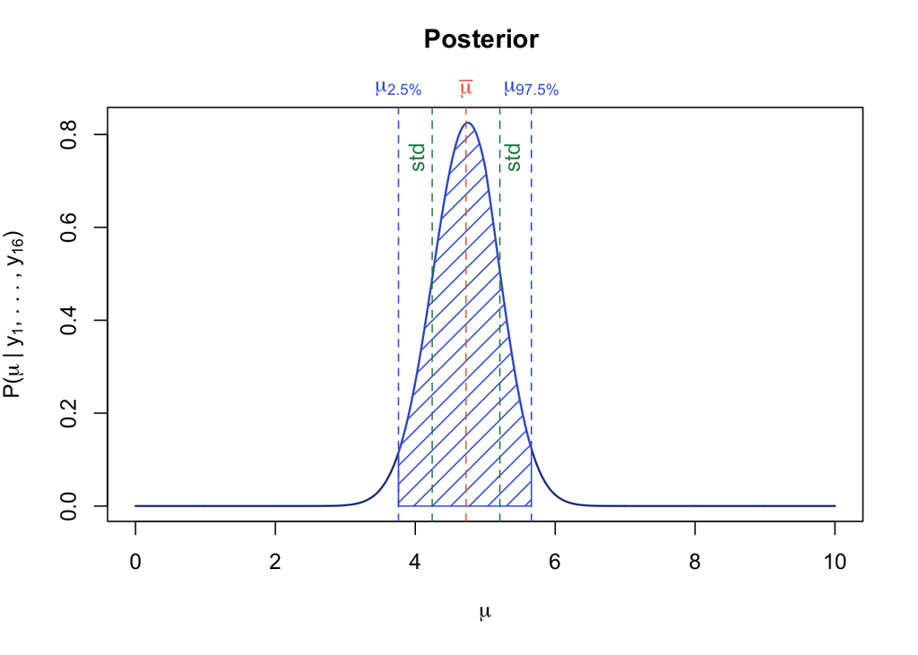

```r
library(latex2exp)
options(repr.plot.width=12, repr.plot.height=10)

plot(mu, post.norm,
     type='l',
     lwd=1.5,
     col = "royalblue4",
     xlab = TeX("$\\mu$"),
     ylab = TeX("P($\\mu$ | y_1,...,y_{16})"),
     main='Posterior \n')

x.between <- mu[mu>=mu1 & mu<=mu2]
x <- c(mu1, x.between, mu2)
dens.between = post.norm[mu>=mu1 & mu<=mu2]
y <- c(0, dens.between, 0)
polygon(x=x, y=y, col='royalblue', density = 10)

abline(v=mu.mean, col="coral2", lty=2)
abline(v=mu1, col="royalblue", lty=2)
abline(v=mu2, col="royalblue", lty=2)
abline(v=mu.mean+post.std, col="seagreen", lty=2)
abline(v=mu.mean-post.std, col="seagreen", lty=2)
text(mu.mean,
     par("usr")[4] + 0.08,
     labels = TeX("$\\bar{\\mu}$"),
     pos = 1, cex = 1, col="coral2", xpd=TRUE)
text(mu.mean+post.std+0.1,
     0.78,
     labels="std",
     pos=1, cex=1, col="seagreen", xpd=TRUE, srt=90)
text(mu.mean-post.std-0.3,
     0.78,
     labels="std",
     pos=1, cex=1, col="seagreen", xpd=TRUE, srt=90)
text(mu1,
     par("usr")[4] + 0.08,
     labels=TeX("$\\mu_{2.5%}$"),
     pos = 1, cex = 1, col="royalblue", xpd=TRUE)
text(mu2,
     par("usr")[4] + 0.08,
     labels=TeX("$\\mu_{97.5%}$"),
     pos = 1, cex = 1, col="royalblue", xpd=TRUE)
```

4. Plot, on the same graph, the prior, the likelihood and the posterior distribution.

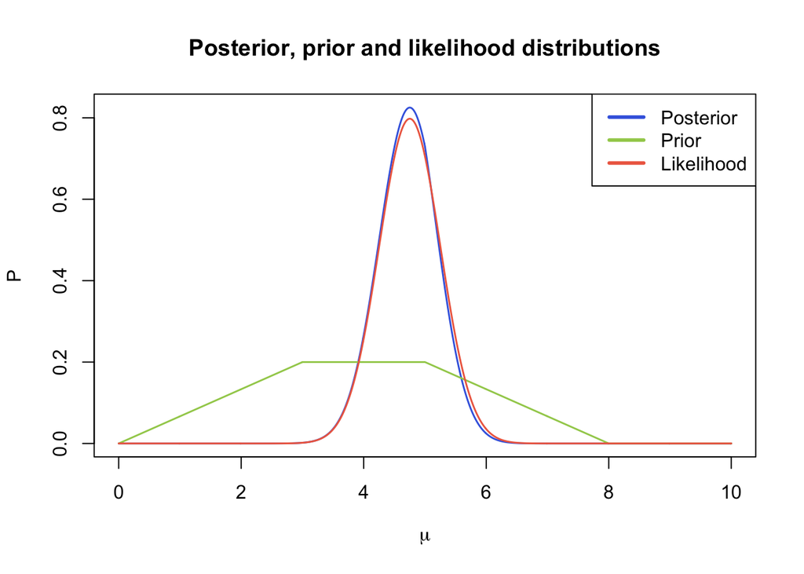

```r
plot(mu, post.norm,
     type = "l",
     lwd = 1.5,
     col = "royalblue",
     xlab = TeX("$\\mu$"),
     ylab = "P",
     main = "Posterior, prior and likelihood distributions")

lines(mu, prior(mu)/15, # normalization
      type = "l",
      lwd = 1.5,
      col = "darkolivegreen3")

lines(mu, likelihood.norm,
      type = "l",
      lwd = 1.5,
      col = "coral2")

legend("topright",
       c("Posterior", "Prior", "Likelihood"),
       lwd = 3,
       col = c("royalblue", "darkolivegreen3", "coral2"),
       lty = c(1, 1, 1))
```

## Exercise 3

In a study on water quality of streams, a high level of bacter X was defined as a level greater than 100 per 100 ml of stream water. $n = 116$ samples were taken from streams having a high environmental impact on pandas. Out of these, $y = 11$ had a high bacter X level.

Indicating with $p$ the probability that a sample of water taken from the stream has a high bacter X level:

1. Find the frequentist estimator for $p$.

```r
n <- 116
y <- 11
p.freq <- 11/116
```

The frequentist estimator for $p$ is $\hat{p} = 0.0948276$.

2. Using a $\text{Beta}(1,10)$ prior for $p$, calculate and plot posterior distribution $P(p|y)$.

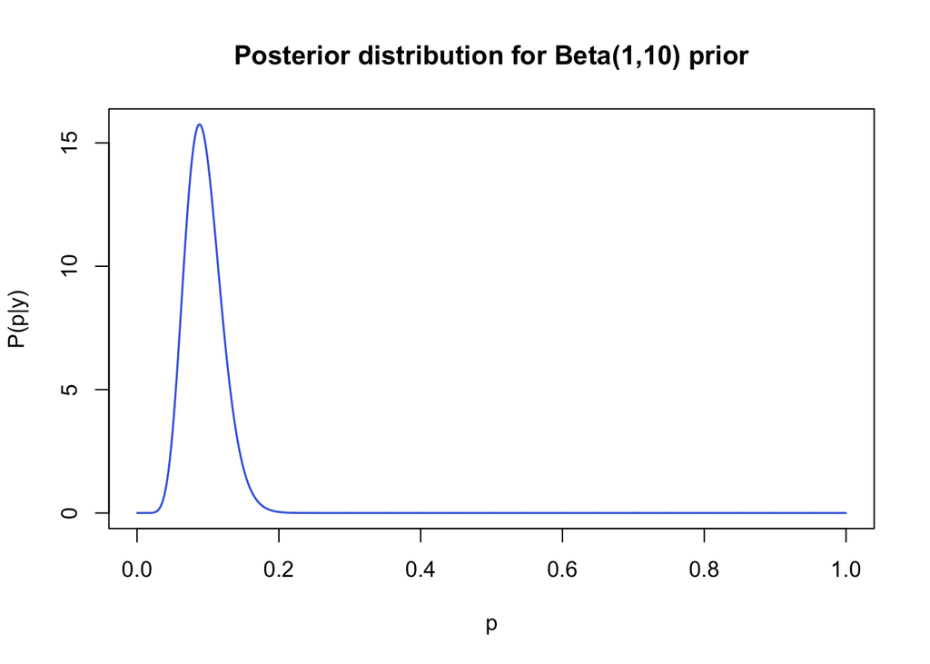

```r
alpha <- 1
beta <- 10
n.sample <- 2000
delta <- 1/n.sample
p <- seq(from=1/(2*n.sample), by=1/n.sample, length.out=n.sample)

prior <- dbeta(p, alpha, beta)

likelihood <- dbinom(y, n, p)

post.star <- dbeta(p, alpha + y, beta + n - y)
post.norm <- post.star/(sum(post.star)*delta)

plot(p, post.norm,
     type = "l",
     lwd = 1.5,
     col = "royalblue",
     ylab = "P(p|y)",
     xlab = "p",
     main = "Posterior distribution for Beta(1,10) prior")
```

3. Find the bayesian estimator for $p$, the posterior mean and variance, and a 95% credible interval.

```r
post.mean <- (alpha + y)/(alpha + beta + n)
post.var <- (alpha + y)*(beta + n - y)/((alpha + beta + n + 1)*(alpha + beta + n)^2)
p1 <- p[which.min(abs(0.025-cumsum(post.norm)*delta))]
p2 <- p[which.min(abs(0.975-cumsum(post.norm)*delta))]
```

The bayesian estimator is the posterior mean, $\bar{p} = 0.0944882$ and the variance is Var $= 6.6843884\times 10^{-4}$. The 95% credible interval is given by $[p_1,p_2] = [0.04975, 0.15075]$.

4. test the hypothesis $H_0 : p = 0.1$ versus $H_1 : p \ne 0.1$ at 5% level of significance with both the frequentist and bayesian approaches.

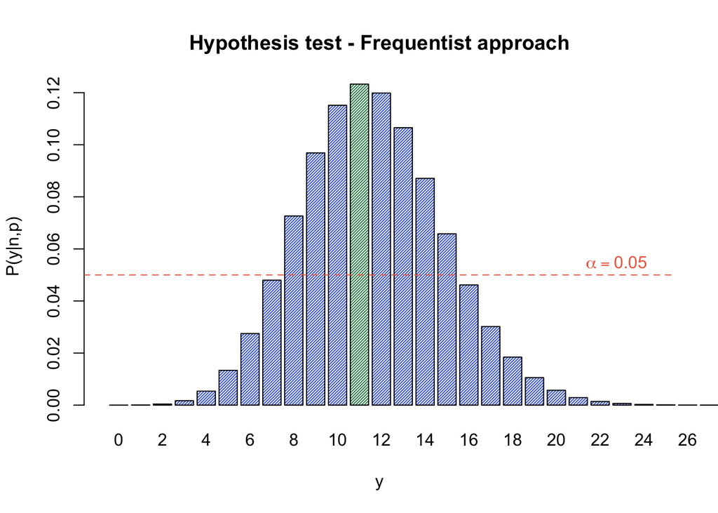

```r
library(latex2exp)
# frequentist approach
p0 <- 0.1
y.samples <- 0:n
sampling.distr <- dbinom(y.samples, n, p0)

barplot(sampling.distr,
        names = y.samples,
        xlim = c(0,30),
        col = ifelse(y.samples == y, "seagreen", "royalblue"),
        density = 50,
        xlab = "y",
        ylab = "P(y|n,p)",
        main = "Hypothesis test - Frequentist approach")

abline(h = 0.05,
       col = "coral2",
       lty = 2)

text(x = 28, y = 0.055, TeX("$\\alpha = 0.05$"), col = "coral2")
```

```r
p.value <- sum(sampling.distr[11:n])

# bayesian approach
p1 <- p[which.min(abs(0.025-cumsum(post.norm)*delta))]
p2 <- p[which.min(abs(0.975-cumsum(post.norm)*delta))]
```

*Frequentist approach*: since p-value $= 0.7341217 > \alpha$, we do not reject the null hypothesis at 5% level of significance.

*Bayesian approach*: since $p_0 = 0.1$ lies inside the credible interval for $p$, we do not reject the null hypothesis at 5% level of significance.

A new measurement, performed one month later on $n = 165$ water samples, gives $y = 9$ high bacter X level.

5. Find the frequentist estimator for $p$.

```r
n <- 165
y <- 9
p.freq <- y/n
```

The frequentist estimator for $p$ is $\hat{p} = 0.0545455$.

6. Find a bayesian estimator for $p$, assuming both a Beta$(1,10)$ prior for $p$, and the posterior probability of the older measurement as the prior for the new one.

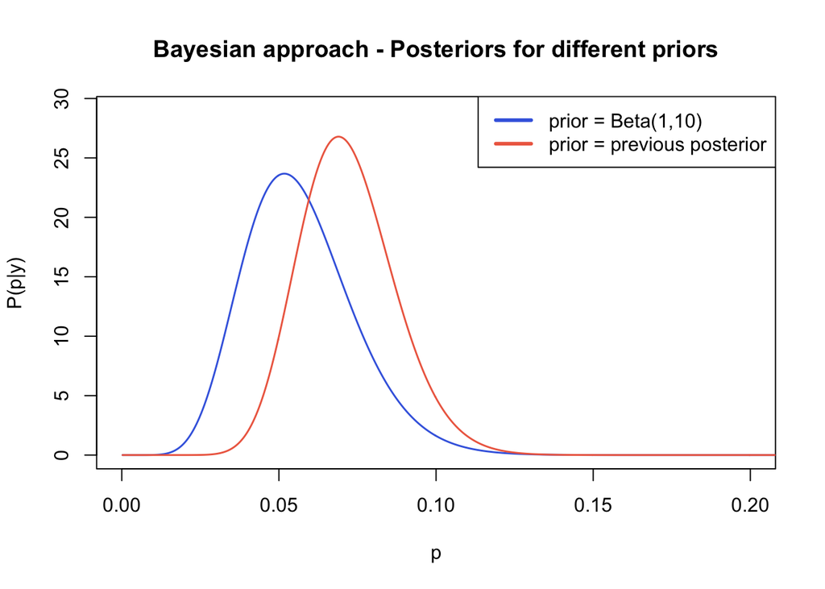

```r
alpha <- 1
beta <- 10
n.sample <- 2000
delta <- 1/n.sample
p <- seq(from=1/(2*n.sample), by=1/n.sample, length.out=n.sample)

b.prior <- dbeta(p, alpha, beta)

likelihood <- dbinom(y, n, p)

b.post.star <- dbeta(p, alpha + y, beta + n - y)
b.post.norm <- b.post.star/(sum(b.post.star)*delta)

plot(p, b.post.norm,
     ylim = c(0, 29),
     xlim = c(0, 0.2),
     type = "l",
     lwd = 1.5,
     col = "royalblue",
     ylab = "P(p|y)",
     xlab = "p",
     main = "Bayesian approach - Posteriors for different priors")

post.new.star <- post.norm*likelihood
post.new.norm <- post.new.star/(sum(post.new.star)*delta)

lines(p, post.new.norm,
      type = "l",
      lwd = 1.5,
      col = "coral2")

legend("topright",
       c("prior = Beta(1,10)", "prior = previous posterior"),
       lwd = 3,
       col = c("royalblue", "coral2"))
```

7. Find the bayesian estimator for $p$, the posterior mean and variance, and a 95% credible interval.

```r
# -- beta
b.post.mean <- (alpha + y)/(alpha + beta + n)
b.post.var <- (alpha + y)*(beta + n - y)/((alpha + beta + n + 1)*(alpha + beta + n)^2)

b.p1 <- p[which.min(abs(0.025-cumsum(b.post.norm)*delta))]
b.p2 <- p[which.min(abs(0.975-cumsum(b.post.norm)*delta))]

# -- prior = previous posterior
p.post.mean <- sum(post.new.norm*p*delta)
#p.post.max <- p[which.max(post.new.norm)]
p.post.var <- sum(post.new.norm*delta*p^2)-p.post.mean^2

p.p1 <- p[which.min(abs(0.025-cumsum(post.new.norm)*delta))]
p.p2 <- p[which.min(abs(0.975-cumsum(post.new.norm)*delta))]
```

**Beta prior**. The bayesian estimator is the posterior mean, $\bar{p} = 0.0568182$ and the variance is Var $= 3.0276766\times 10^{-4}$. The 95% credible interval is given by $[p_1,p_2] = [0.02725, 0.09525]$.

**Previous posterior as prior**. The bayesian estimator is the posterior mean, $\bar{p} = 0.0719178$ and the variance is Var $= 2.2780081\times 10^{-4}$. The 95% credible interval is given by $[p_1,p_2] = [0.04475, 0.10375]$.

8. test the hypothesis $H_0 : p = 0.1$ versus $H_1 : p \ne 0.1$ at 5% level of significance with both the frequentist and bayesian approaches.

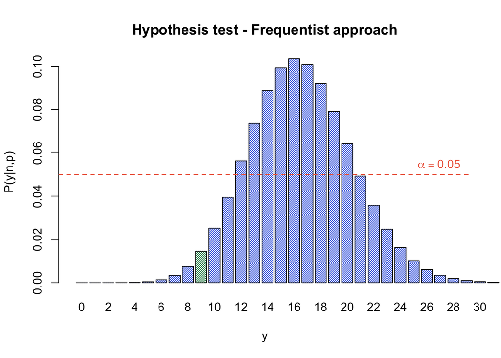

```r
library(latex2exp)
# frequentist approach
p0 <- 0.1
y.samples <- 0:n
sampling.distr <- dbinom(y.samples, n, p0)

barplot(sampling.distr,
        names = y.samples,
        xlim = c(0,34.5),
        col = ifelse(y.samples == y, "seagreen", "royalblue"),
        density = 50,
        xlab = "y",
        ylab = "P(y|n,p)",
        main = "Hypothesis test - Frequentist approach")

abline(h = 0.05,
       col = "coral2",
       lty = 2)

text(x = 33, y = 0.055, TeX("$\\alpha = 0.05$"), col = "coral2")
```

```r
p.value <-  dbinom(y, n, p0)

# bayesian approach
b.p1 <- p[which.min(abs(0.025-cumsum(b.post.norm)*delta))]
b.p2 <- p[which.min(abs(0.975-cumsum(b.post.norm)*delta))]

# bayesian approach
p.p1 <- p[which.min(abs(0.025-cumsum(post.new.norm)*delta))]
p.p2 <- p[which.min(abs(0.975-cumsum(post.new.norm)*delta))]
```

**Bayesian approach**

*Beta prior*: since $p_0 = 0.1$ does not lie inside the credible interval for $p$, $[p_1,p_2] = [0.02725, 0.09525]$, we reject the null hypothesis at 5% level of significance.

*Previous posterior as prior*: since $p_0 = 0.1$ lies inside the credible interval for $p$, $[p_1,p_2] = [0.04475, 0.10375]$, we do not reject the null hypothesis at 5% level of significance.